# testing_functions

```python
import matplotlib.pyplot as plt
%matplotlib inline
```

```python
import assignment2_functions
import pandas as pd
from sklearn.tree import DecisionTreeClassifier
from sklearn.model_selection import train_test_split
from sklearn import metrics
from sklearn import tree
from sklearn.tree import export_graphviz
import graphviz
import numpy as np
```

## Part 1: Explore Data

```python
df = assignment2_functions.file_to_dataframe("credit-data.csv")
```

```python
df.head()
```

|  | PersonID | SeriousDlqin2yrs | RevolvingUtilizationOfUnsecuredLines | age | zipcode | NumberOfTime30-59DaysPastDueNotWorse | DebtRatio | MonthlyIncome | NumberOfOpenCreditLinesAndLoans | NumberOfTimes90DaysLate | NumberRealEstateLoansOrLines | NumberOfTime60-89DaysPastDueNotWorse | NumberOfDependents |
| --- | --- | --- | --- | --- | --- | --- | --- | --- | --- | --- | --- | --- | --- |
| 0 | 98976 | 0 | 1.000000 | 55 | 60601 | 0 | 505.000000 | 0.0 | 2 | 0 | 0 | 0 | 0.0 |
| 1 | 98991 | 0 | 0.547745 | 71 | 60601 | 0 | 0.459565 | 15666.0 | 7 | 0 | 2 | 0 | 0.0 |
| 2 | 99012 | 0 | 0.044280 | 51 | 60601 | 0 | 0.014520 | 4200.0 | 5 | 0 | 0 | 0 | 0.0 |
| 3 | 99023 | 0 | 0.914249 | 55 | 60601 | 4 | 0.794875 | 9052.0 | 12 | 0 | 3 | 0 | 0.0 |
| 4 | 99027 | 0 | 0.026599 | 45 | 60601 | 0 | 0.049966 | 10406.0 | 4 | 0 | 0 | 0 | 2.0 |

### First, when exploring the data I wanted to show descriptive statistics, correlations between the variables, and understand which columns in the dataset have NA values

#### From the summary below, we see that the df has NA values in the MonthlyIncome and NumberOfDependents columns

```python
na_summary = assignment2_functions.na_summary(df)
na_summary
```

```
PersonID                                False
SeriousDlqin2yrs                        False
RevolvingUtilizationOfUnsecuredLines    False
age                                     False
zipcode                                 False
NumberOfTime30-59DaysPastDueNotWorse    False
DebtRatio                               False
MonthlyIncome                            True
NumberOfOpenCreditLinesAndLoans         False
NumberOfTimes90DaysLate                 False
NumberRealEstateLoansOrLines            False
NumberOfTime60-89DaysPastDueNotWorse    False
NumberOfDependents                       True
dtype: bool
```

#### The descriptive stats below show that the variables Debt Ratio and RevolvingUtilizationOfUnsecuredLines, for example, have a really large range of values.

```python
descriptive_stats = assignment2_functions.describe_data(df)
descriptive_stats
```

|  | PersonID | SeriousDlqin2yrs | RevolvingUtilizationOfUnsecuredLines | age | zipcode | NumberOfTime30-59DaysPastDueNotWorse | DebtRatio | MonthlyIncome | NumberOfOpenCreditLinesAndLoans | NumberOfTimes90DaysLate | NumberRealEstateLoansOrLines | NumberOfTime60-89DaysPastDueNotWorse | NumberOfDependents |
| --- | --- | --- | --- | --- | --- | --- | --- | --- | --- | --- | --- | --- | --- |
| count | 41016.000000 | 41016.000000 | 41016.00000 | 41016.000000 | 41016.000000 | 41016.000000 | 41016.000000 | 3.304200e+04 | 41016.000000 | 41016.000000 | 41016.000000 | 41016.000000 | 39979.000000 |
| mean | 115800.154598 | 0.161400 | 6.37587 | 51.683489 | 60623.824166 | 0.589233 | 331.458137 | 6.578996e+03 | 8.403477 | 0.419592 | 1.008801 | 0.371587 | 0.773231 |
| std | 28112.723511 | 0.367904 | 221.61895 | 14.746880 | 11.984357 | 5.205628 | 1296.109695 | 1.344683e+04 | 5.207324 | 5.190382 | 1.153826 | 5.169641 | 1.121269 |
| min | 22.000000 | 0.000000 | 0.00000 | 21.000000 | 60601.000000 | 0.000000 | 0.000000 | 0.000000e+00 | 0.000000 | 0.000000 | 0.000000 | 0.000000 | 0.000000 |
| 25% | 106539.750000 | 0.000000 | 0.03431 | 41.000000 | 60618.000000 | 0.000000 | 0.176375 | 3.333000e+03 | 5.000000 | 0.000000 | 0.000000 | 0.000000 | 0.000000 |
| 50% | 119901.500000 | 0.000000 | 0.18973 | 51.000000 | 60625.000000 | 0.000000 | 0.369736 | 5.250000e+03 | 8.000000 | 0.000000 | 1.000000 | 0.000000 | 0.000000 |
| 75% | 134698.250000 | 0.000000 | 0.66716 | 62.000000 | 60629.000000 | 0.000000 | 0.866471 | 8.055750e+03 | 11.000000 | 0.000000 | 2.000000 | 0.000000 | 1.000000 |
| max | 149999.000000 | 1.000000 | 22000.00000 | 109.000000 | 60644.000000 | 98.000000 | 106885.000000 | 1.794060e+06 | 56.000000 | 98.000000 | 32.000000 | 98.000000 | 13.000000 |

#### I plotted histograms to better understand the distribution of the data. Of the numeric variables, age seems to be the most normally distributed, while the other variables are more skewed. The skewedness likely comes from the presence of outliers in most cases. I will explore outliers more thoroughly later.

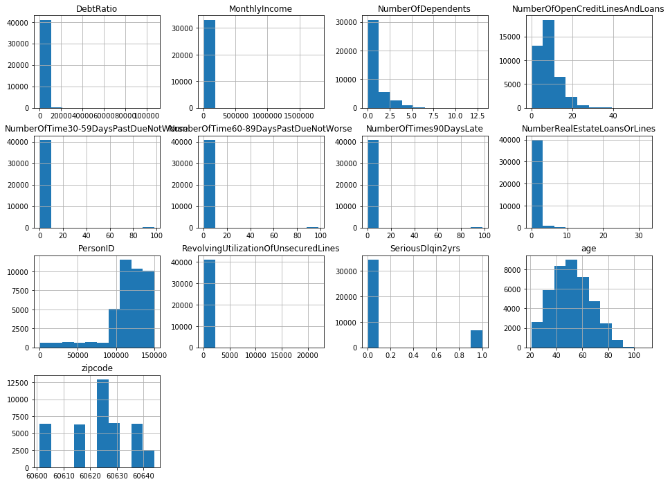

```python
assignment2_functions.histograms(df)
```

#### I used a few approaches to identify correlations between variables in the data. Below I have provided a correlation table and correlation matrix corresponding to that table. Additionally, it is possible to see the correlation between variables using pairplots.

```python
corr_table = assignment2_functions.correlations(df)
corr_table
```

|  | PersonID | SeriousDlqin2yrs | RevolvingUtilizationOfUnsecuredLines | age | zipcode | NumberOfTime30-59DaysPastDueNotWorse | DebtRatio | MonthlyIncome | NumberOfOpenCreditLinesAndLoans | NumberOfTimes90DaysLate | NumberRealEstateLoansOrLines | NumberOfTime60-89DaysPastDueNotWorse | NumberOfDependents |
| --- | --- | --- | --- | --- | --- | --- | --- | --- | --- | --- | --- | --- | --- |
| PersonID | 1.000000 | -0.622739 | 0.004499 | 0.108533 | -0.021010 | -0.082598 | 0.006864 | 0.019755 | 0.022669 | -0.076856 | 0.004341 | -0.065353 | -0.030364 |
| SeriousDlqin2yrs | -0.622739 | 1.000000 | -0.004586 | -0.173728 | -0.045051 | 0.149334 | -0.013502 | -0.032810 | -0.039898 | 0.139609 | -0.010641 | 0.121886 | 0.065708 |
| RevolvingUtilizationOfUnsecuredLines | 0.004499 | -0.004586 | 1.000000 | -0.008003 | 0.006009 | -0.001999 | 0.022250 | 0.005832 | -0.014590 | -0.001686 | 0.004763 | -0.001413 | 0.005342 |
| age | 0.108533 | -0.173728 | -0.008003 | 1.000000 | 0.005408 | -0.068696 | 0.038828 | 0.048138 | 0.159866 | -0.069036 | 0.049168 | -0.063622 | -0.211002 |
| zipcode | -0.021010 | -0.045051 | 0.006009 | 0.005408 | 1.000000 | -0.002424 | 0.002088 | -0.004980 | -0.009214 | -0.001487 | 0.003141 | -0.001198 | -0.001744 |
| NumberOfTime30-59DaysPastDueNotWorse | -0.082598 | 0.149334 | -0.001999 | -0.068696 | -0.002424 | 1.000000 | -0.011620 | -0.015224 | -0.070704 | 0.984465 | -0.037863 | 0.988530 | -0.007840 |
| DebtRatio | 0.006864 | -0.013502 | 0.022250 | 0.038828 | 0.002088 | -0.011620 | 1.000000 | -0.022988 | 0.082791 | -0.014790 | 0.177858 | -0.013290 | -0.070558 |
| MonthlyIncome | 0.019755 | -0.032810 | 0.005832 | 0.048138 | -0.004980 | -0.015224 | -0.022988 | 1.000000 | 0.107100 | -0.017954 | 0.127313 | -0.015336 | 0.060528 |
| NumberOfOpenCreditLinesAndLoans | 0.022669 | -0.039898 | -0.014590 | 0.159866 | -0.009214 | -0.070704 | 0.082791 | 0.107100 | 1.000000 | -0.098176 | 0.442776 | -0.087154 | 0.060218 |
| NumberOfTimes90DaysLate | -0.076856 | 0.139609 | -0.001686 | -0.069036 | -0.001487 | 0.984465 | -0.014790 | -0.017954 | -0.098176 | 1.000000 | -0.054661 | 0.992143 | -0.015737 |
| NumberRealEstateLoansOrLines | 0.004341 | -0.010641 | 0.004763 | 0.049168 | 0.003141 | -0.037863 | 0.177858 | 0.127313 | 0.442776 | -0.054661 | 1.000000 | -0.047996 | 0.114880 |
| NumberOfTime60-89DaysPastDueNotWorse | -0.065353 | 0.121886 | -0.001413 | -0.063622 | -0.001198 | 0.988530 | -0.013290 | -0.015336 | -0.087154 | 0.992143 | -0.047996 | 1.000000 | -0.016493 |
| NumberOfDependents | -0.030364 | 0.065708 | 0.005342 | -0.211002 | -0.001744 | -0.007840 | -0.070558 | 0.060528 | 0.060218 | -0.015737 | 0.114880 | -0.016493 | 1.000000 |

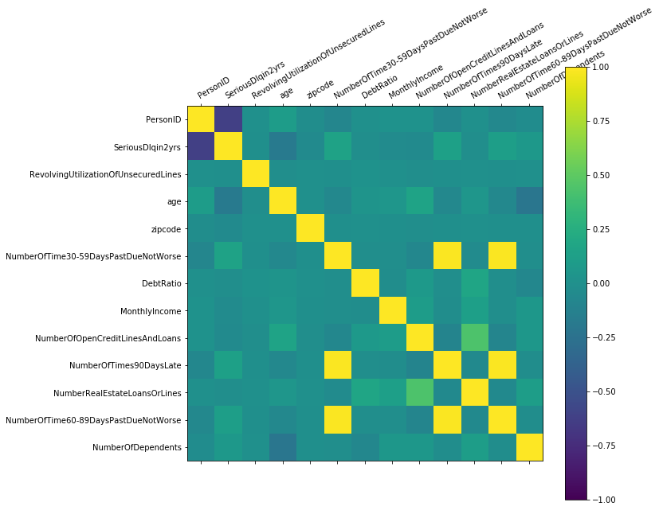

```python
corr_matrix = assignment2_functions.correlation_matrix(corr_table)
```

#### The correlation matrix above shows that NumberOfTime30-59DaysPastDueNotWorse and NumberOfTime60-89DaysPastDueNotWorse are highly correlated, and NumberOfTimes90DaysLate are all highly correlated. The pairplot below confirms this.

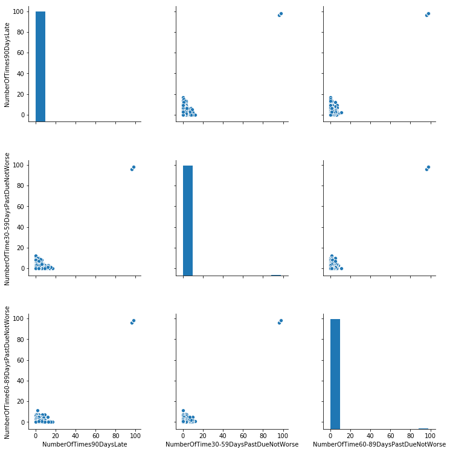

```python
vars_to_describe = ['NumberOfTimes90DaysLate', 'NumberOfTime30-59DaysPastDueNotWorse',  'NumberOfTime60-89DaysPastDueNotWorse']
assignment2_functions.pairplot(df, vars_to_describe)
```

#### The above pairplots also show outliers in the data. I took two approaches to identify outliers. The first was to plot boxplots and visually see the outliers, and the second was to use the IQR to filter columns with outliers. The boxplots show outliers in all the numeric variables.

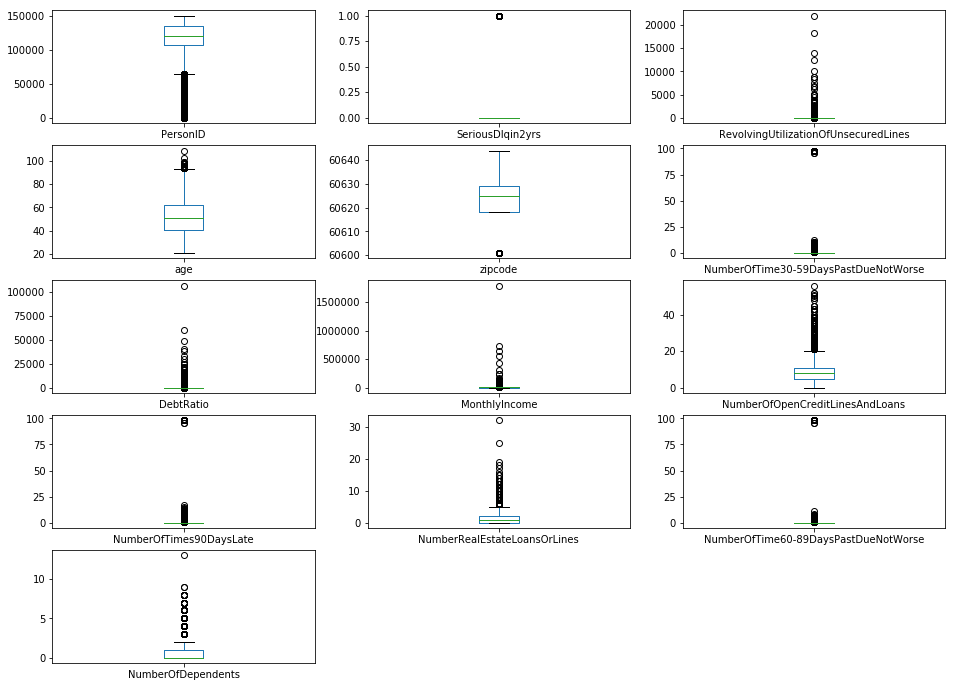

```python
assignment2_functions.boxplots(df)
```

#### It is also possible to see which rows had outliers for a specific variable or list of variables. For example, if I wanted to see which rows had outliers for the age variable, I could do so like I have done below:

```python
outlier_vars = ['age']
outliers = assignment2_functions.identify_ol(df, outlier_vars)
outliers.head()
```

|  | age |
| --- | --- |
| 1159 | 97 |
| 1806 | 94 |
| 1932 | 97 |
| 3738 | 103 |
| 3876 | 95 |

#### Finally, I took out all the outliers for numeric columns, and plotted the distributions without outliers to see how the distributions would be changed. The plots show that age, NumberOfOpenCreditLinesAndLoans and MonthlyIncome become more normally distributed, whereas the other variables remain discrete/skewed.

```python
all_outliers = assignment2_functions.identify_ol(df, ['RevolvingUtilizationOfUnsecuredLines', 'age', 'NumberOfTime30-59DaysPastDueNotWorse', 'DebtRatio', 'MonthlyIncome', 'NumberOfOpenCreditLinesAndLoans', 'NumberOfTimes90DaysLate', 'NumberOfTime60-89DaysPastDueNotWorse', 'NumberOfDependents'])
data_without_outliers = pd.merge(df, all_outliers, how='outer', indicator=True)
data_without_outliers = data_without_outliers.loc[data_without_outliers._merge == 'left_only']
data_without_outliers.drop(labels='_merge', axis=1, inplace=True)
data_without_outliers
```

|  | PersonID | SeriousDlqin2yrs | RevolvingUtilizationOfUnsecuredLines | age | zipcode | NumberOfTime30-59DaysPastDueNotWorse | DebtRatio | MonthlyIncome | NumberOfOpenCreditLinesAndLoans | NumberOfTimes90DaysLate | NumberRealEstateLoansOrLines | NumberOfTime60-89DaysPastDueNotWorse | NumberOfDependents |
| --- | --- | --- | --- | --- | --- | --- | --- | --- | --- | --- | --- | --- | --- |
| 2 | 99012 | 0 | 0.044280 | 51 | 60601 | 0 | 0.014520 | 4200.0 | 5 | 0 | 0 | 0 | 0.0 |
| 4 | 99027 | 0 | 0.026599 | 45 | 60601 | 0 | 0.049966 | 10406.0 | 4 | 0 | 0 | 0 | 2.0 |
| 5 | 99033 | 0 | 0.142231 | 57 | 60601 | 0 | 0.015332 | 13500.0 | 6 | 0 | 0 | 0 | 0.0 |
| 6 | 99044 | 0 | 0.047601 | 48 | 60601 | 0 | 0.474609 | 3583.0 | 13 | 0 | 1 | 0 | 1.0 |
| 7 | 99048 | 0 | 0.022141 | 34 | 60601 | 0 | 0.003332 | 2700.0 | 2 | 0 | 0 | 0 | 1.0 |
| 8 | 99056 | 0 | 0.241805 | 30 | 60601 | 0 | 0.864452 | 3400.0 | 13 | 0 | 1 | 0 | 1.0 |
| 9 | 99058 | 0 | 0.036181 | 71 | 60601 | 0 | 0.568798 | 5050.0 | 16 | 0 | 2 | 0 | 0.0 |
| 10 | 99062 | 0 | 0.000000 | 50 | 60601 | 0 | 0.541985 | 2750.0 | 6 | 0 | 1 | 0 | 0.0 |
| 11 | 99104 | 0 | 0.000000 | 26 | 60601 | 0 | 0.000000 | 2901.0 | 2 | 0 | 0 | 0 | 0.0 |
| 12 | 99105 | 0 | 0.007721 | 64 | 60601 | 0 | 0.606957 | 2500.0 | 12 | 0 | 1 | 0 | 0.0 |
| 15 | 99176 | 0 | 0.000000 | 66 | 60601 | 0 | 0.000000 | 3393.0 | 3 | 0 | 0 | 0 | 0.0 |
| 16 | 99193 | 0 | 1.000000 | 32 | 60601 | 0 | 0.388190 | 3894.0 | 3 | 0 | 1 | 0 | 2.0 |
| 17 | 99200 | 0 | 0.056329 | 64 | 60601 | 0 | 0.015332 | 9000.0 | 7 | 0 | 0 | 0 | 0.0 |
| 19 | 99217 | 0 | 0.029997 | 76 | 60601 | 0 | 0.003636 | 4400.0 | 7 | 0 | 0 | 0 | 0.0 |
| 21 | 99224 | 0 | 0.099190 | 41 | 60601 | 0 | 0.445200 | 4999.0 | 7 | 0 | 2 | 0 | 0.0 |
| 22 | 99233 | 0 | 0.019669 | 60 | 60601 | 0 | 0.281566 | 9400.0 | 16 | 0 | 2 | 0 | 1.0 |
| 23 | 99238 | 0 | 0.001097 | 43 | 60601 | 0 | 0.296134 | 5250.0 | 8 | 0 | 1 | 0 | 0.0 |
| 25 | 99249 | 0 | 0.325003 | 56 | 60601 | 0 | 0.943579 | 7000.0 | 7 | 0 | 2 | 0 | 2.0 |
| 26 | 99262 | 0 | 1.000000 | 73 | 60601 | 0 | 0.812552 | 2405.0 | 3 | 0 | 1 | 0 | 0.0 |
| 28 | 99271 | 0 | 0.125351 | 34 | 60601 | 0 | 0.926030 | 2500.0 | 5 | 0 | 2 | 0 | 0.0 |
| 29 | 99284 | 0 | 0.000000 | 39 | 60601 | 0 | 0.440096 | 5416.0 | 6 | 0 | 2 | 0 | 2.0 |
| 30 | 99289 | 0 | 1.000000 | 30 | 60601 | 0 | 0.815092 | 2000.0 | 3 | 0 | 1 | 0 | 1.0 |
| 35 | 99323 | 0 | 0.000000 | 32 | 60601 | 0 | 0.000000 | 3360.0 | 3 | 0 | 0 | 0 | 1.0 |
| 36 | 99371 | 0 | 0.026069 | 49 | 60601 | 0 | 0.666344 | 6200.0 | 10 | 0 | 2 | 0 | 2.0 |
| 38 | 99378 | 0 | 0.133801 | 55 | 60601 | 0 | 0.037520 | 10500.0 | 10 | 0 | 0 | 0 | 0.0 |
| 39 | 99411 | 0 | 0.053313 | 52 | 60601 | 0 | 0.191122 | 8334.0 | 6 | 0 | 1 | 0 | 0.0 |
| 40 | 99415 | 0 | 0.041988 | 62 | 60601 | 0 | 0.413062 | 3444.0 | 11 | 0 | 2 | 0 | 1.0 |
| 41 | 99417 | 0 | 0.253187 | 56 | 60601 | 0 | 0.720538 | 6100.0 | 11 | 0 | 2 | 0 | 0.0 |
| 43 | 99424 | 0 | 0.027881 | 70 | 60601 | 0 | 0.421020 | 3234.0 | 17 | 0 | 1 | 0 | 1.0 |
| 46 | 99458 | 0 | 0.040805 | 57 | 60601 | 0 | 0.251524 | 3116.0 | 3 | 0 | 1 | 0 | 0.0 |
| ... | ... | ... | ... | ... | ... | ... | ... | ... | ... | ... | ... | ... | ... |
| 40999 | 123174 | 0 | 0.006599 | 70 | 60644 | 0 | 0.000451 | 2217.0 | 3 | 0 | 0 | 0 | 0.0 |
| 41002 | 123206 | 0 | 0.118255 | 48 | 60644 | 0 | 1.038740 | 4000.0 | 14 | 0 | 3 | 0 | 0.0 |
| 41003 | 123209 | 0 | 0.002679 | 73 | 60644 | 0 | 0.001783 | 2804.0 | 4 | 0 | 0 | 0 | 0.0 |
| 41004 | 123223 | 0 | 0.186848 | 65 | 60644 | 0 | 0.199594 | 3451.0 | 7 | 0 | 0 | 0 | 0.0 |
| 41005 | 123240 | 0 | 0.039812 | 30 | 60644 | 0 | 0.164253 | 2416.0 | 9 | 0 | 0 | 0 | 0.0 |
| 41006 | 123244 | 0 | 0.108956 | 60 | 60644 | 0 | 0.469555 | 3300.0 | 7 | 0 | 1 | 0 | 0.0 |
| 41007 | 123247 | 0 | 1.000000 | 56 | 60644 | 0 | 0.085699 | 7397.0 | 3 | 0 | 1 | 0 | 0.0 |
| 41008 | 123252 | 0 | 0.011217 | 37 | 60644 | 0 | 0.291674 | 5800.0 | 4 | 0 | 1 | 0 | 0.0 |
| 41010 | 123264 | 0 | 0.054102 | 71 | 60644 | 0 | 0.265173 | 10000.0 | 6 | 0 | 3 | 0 | 1.0 |
| 41011 | 123284 | 0 | 0.086294 | 62 | 60644 | 0 | 0.218689 | 6163.0 | 10 | 0 | 2 | 0 | 0.0 |
| 41013 | 123311 | 0 | 0.000000 | 24 | 60644 | 0 | 0.000000 | 864.0 | 1 | 0 | 0 | 0 | 0.0 |
| 41016 | 123379 | 0 | 0.435914 | 47 | 60644 | 0 | 0.084809 | 13500.0 | 6 | 0 | 0 | 0 | 0.0 |
| 41018 | 123426 | 0 | 0.306655 | 58 | 60644 | 0 | 0.169335 | 12867.0 | 13 | 0 | 0 | 0 | 1.0 |
| 41022 | 123487 | 0 | 0.573328 | 49 | 60644 | 0 | 0.286145 | 6300.0 | 5 | 0 | 1 | 0 | 2.0 |
| 41028 | 123529 | 0 | 0.470070 | 36 | 60644 | 0 | 0.403058 | 5100.0 | 8 | 0 | 0 | 0 | 2.0 |
| 41029 | 123532 | 0 | 1.000000 | 22 | 60644 | 0 | 0.000000 | 1000.0 | 1 | 0 | 0 | 0 | 0.0 |
| 41030 | 123538 | 0 | 0.010451 | 90 | 60644 | 0 | 0.003665 | 3000.0 | 12 | 0 | 0 | 0 | 0.0 |
| 41031 | 123540 | 0 | 0.048568 | 50 | 60644 | 0 | 0.002411 | 7465.0 | 3 | 0 | 0 | 0 | 0.0 |
| 41032 | 123541 | 0 | 0.285436 | 70 | 60644 | 0 | 0.346093 | 7000.0 | 13 | 0 | 1 | 0 | 1.0 |
| 41035 | 123615 | 0 | 0.004838 | 48 | 60644 | 0 | 0.197313 | 5432.0 | 7 | 0 | 1 | 0 | 1.0 |
| 41037 | 123641 | 0 | 0.020700 | 51 | 60644 | 0 | 0.265573 | 10000.0 | 8 | 0 | 1 | 0 | 0.0 |
| 41039 | 123650 | 0 | 0.103721 | 43 | 60644 | 0 | 0.229422 | 8333.0 | 4 | 0 | 1 | 0 | 0.0 |
| 41040 | 123654 | 0 | 0.014896 | 67 | 60644 | 0 | 1.217976 | 4683.0 | 10 | 0 | 3 | 0 | 0.0 |
| 41041 | 123657 | 0 | 0.545411 | 47 | 60644 | 0 | 0.666619 | 7000.0 | 8 | 0 | 3 | 0 | 2.0 |
| 41043 | 123660 | 0 | 0.725367 | 45 | 60644 | 0 | 0.609262 | 8744.0 | 16 | 0 | 1 | 0 | 0.0 |
| 41044 | 123661 | 0 | 0.016898 | 75 | 60644 | 0 | 0.079534 | 5833.0 | 8 | 0 | 1 | 0 | 0.0 |
| 41045 | 123664 | 0 | 0.010978 | 92 | 60644 | 0 | 0.004199 | 3333.0 | 10 | 0 | 0 | 0 | 0.0 |
| 41046 | 123667 | 0 | 0.146501 | 91 | 60644 | 0 | 0.010053 | 2088.0 | 1 | 0 | 0 | 0 | 0.0 |
| 41047 | 123679 | 0 | 0.117274 | 62 | 60644 | 0 | 0.742110 | 9220.0 | 19 | 0 | 3 | 0 | 2.0 |
| 41048 | 123687 | 0 | 0.822783 | 51 | 60644 | 0 | 0.366492 | 2100.0 | 9 | 0 | 0 | 0 | 0.0 |

20406 rows × 13 columns

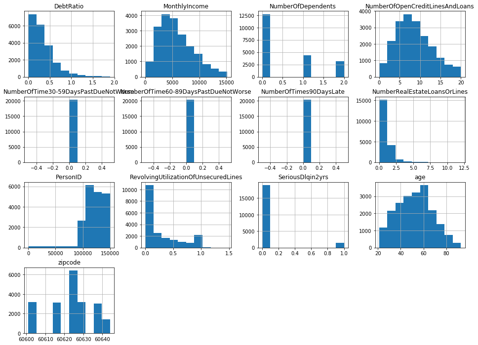

```python
assignment2_functions.histograms(data_without_outliers)
```

## Part 2: Process Data

#### Below, I process the data in the columns that have NA values, and I replace the NAs with the median of the values in that column. I then summarize NAs for the columns again to make sure that there are no remaining columns with NA values

```python
df = assignment2_functions.pre_process(df)
na_summary = assignment2_functions.na_summary(df)
na_summary
```

```
PersonID                                False
SeriousDlqin2yrs                        False
RevolvingUtilizationOfUnsecuredLines    False
age                                     False
zipcode                                 False
NumberOfTime30-59DaysPastDueNotWorse    False
DebtRatio                               False
MonthlyIncome                           False
NumberOfOpenCreditLinesAndLoans         False
NumberOfTimes90DaysLate                 False
NumberRealEstateLoansOrLines            False
NumberOfTime60-89DaysPastDueNotWorse    False
NumberOfDependents                      False
dtype: bool
```

## Part 3: Generate Features

#### Based on my analysis of outliers above, I decided to discretize age, MonthlyIncome, and NumberOfOpenCreditLinesAndLoans, because their distributions seem to be the most affected by the presence of outliers.

```python
vars_to_discretize = ['age', 'MonthlyIncome', 'NumberOfOpenCreditLinesAndLoans']
df = assignment2_functions.discretize(df, vars_to_discretize)
df.head()
```

|  | PersonID | SeriousDlqin2yrs | RevolvingUtilizationOfUnsecuredLines | age | zipcode | NumberOfTime30-59DaysPastDueNotWorse | DebtRatio | MonthlyIncome | NumberOfOpenCreditLinesAndLoans | NumberOfTimes90DaysLate | NumberRealEstateLoansOrLines | NumberOfTime60-89DaysPastDueNotWorse | NumberOfDependents | age_discrete | MonthlyIncome_discrete | NumberOfOpenCreditLinesAndLoans_discrete |
| --- | --- | --- | --- | --- | --- | --- | --- | --- | --- | --- | --- | --- | --- | --- | --- | --- |
| 0 | 98976 | 0 | 1.000000 | 55 | 60601 | 0 | 505.000000 | 0.0 | 2 | 0 | 0 | 0 | 0.0 | (51.0, 55.0] | (-0.001, 2267.0] | (-0.001, 3.0] |
| 1 | 98991 | 0 | 0.547745 | 71 | 60601 | 0 | 0.459565 | 15666.0 | 7 | 0 | 2 | 0 | 0.0 | (64.0, 72.0] | (10583.0, 1794060.0] | (6.0, 8.0] |
| 2 | 99012 | 0 | 0.044280 | 51 | 60601 | 0 | 0.014520 | 4200.0 | 5 | 0 | 0 | 0 | 0.0 | (47.0, 51.0] | (3330.0, 4230.0] | (4.0, 5.0] |
| 3 | 99023 | 0 | 0.914249 | 55 | 60601 | 4 | 0.794875 | 9052.0 | 12 | 0 | 3 | 0 | 0.0 | (51.0, 55.0] | (8094.0, 10583.0] | (10.0, 12.0] |
| 4 | 99027 | 0 | 0.026599 | 45 | 60601 | 0 | 0.049966 | 10406.0 | 4 | 0 | 0 | 0 | 2.0 | (43.0, 47.0] | (8094.0, 10583.0] | (3.0, 4.0] |

#### I then made dummy values for zipcode, which appears to be the only categorical variable in the dataset. I also made dummy variables for the three variables I just discretized.

```python
df = assignment2_functions.categorize(df, ['zipcode', 'MonthlyIncome_discrete', 'NumberOfOpenCreditLinesAndLoans_discrete', 'age_discrete'])
df.head()
```

|  | PersonID | SeriousDlqin2yrs | RevolvingUtilizationOfUnsecuredLines | age | NumberOfTime30-59DaysPastDueNotWorse | DebtRatio | MonthlyIncome | NumberOfOpenCreditLinesAndLoans | NumberOfTimes90DaysLate | NumberRealEstateLoansOrLines | ... | age_discrete_(20.999, 32.0] | age_discrete_(32.0, 38.0] | age_discrete_(38.0, 43.0] | age_discrete_(43.0, 47.0] | age_discrete_(47.0, 51.0] | age_discrete_(51.0, 55.0] | age_discrete_(55.0, 60.0] | age_discrete_(60.0, 64.0] | age_discrete_(64.0, 72.0] | age_discrete_(72.0, 109.0] |
| --- | --- | --- | --- | --- | --- | --- | --- | --- | --- | --- | --- | --- | --- | --- | --- | --- | --- | --- | --- | --- | --- |
| 0 | 98976 | 0 | 1.000000 | 55 | 0 | 505.000000 | 0.0 | 2 | 0 | 0 | ... | 0 | 0 | 0 | 0 | 0 | 1 | 0 | 0 | 0 | 0 |
| 1 | 98991 | 0 | 0.547745 | 71 | 0 | 0.459565 | 15666.0 | 7 | 0 | 2 | ... | 0 | 0 | 0 | 0 | 0 | 0 | 0 | 0 | 1 | 0 |
| 2 | 99012 | 0 | 0.044280 | 51 | 0 | 0.014520 | 4200.0 | 5 | 0 | 0 | ... | 0 | 0 | 0 | 0 | 1 | 0 | 0 | 0 | 0 | 0 |
| 3 | 99023 | 0 | 0.914249 | 55 | 4 | 0.794875 | 9052.0 | 12 | 0 | 3 | ... | 0 | 0 | 0 | 0 | 0 | 1 | 0 | 0 | 0 | 0 |
| 4 | 99027 | 0 | 0.026599 | 45 | 0 | 0.049966 | 10406.0 | 4 | 0 | 0 | ... | 0 | 0 | 0 | 1 | 0 | 0 | 0 | 0 | 0 | 0 |

5 rows × 48 columns

## Part 4: Selecting Features and Training a Model

#### Now that I've created discretized and dummy variables, I drop the original columns from the data. I also drop highly collinear columns (NumberOfTime30-59DaysPastDueNotWorse and NumberOfTime60-89DaysPastDueNotWorse)

```python
selected_features = [col for col in df if col.startswith('zipcode') or col not in ['PersonID', 'SeriousDlqin2yrs', 'zipcode', 'age', 'MonthlyIncome', 'NumberOfTime30-59DaysPastDueNotWorse', 'NumberOfTime60-89DaysPastDueNotWorse','NumberOfOpenCreditLinesAndLoans', 'NumberOfOpenCreditLinesAndLoans_discrete', 'MonthlyIncome_discrete', 'age_discrete']]
selected_y = 'SeriousDlqin2yrs'
```

#### Now I create train, test splits using these selected features

```python
x_train, x_test, y_train, y_test = assignment2_functions.split_data(df, selected_features, selected_y, test_size=0.3)
```

```python
y_pred, dec_tree = assignment2_functions.build_classifier(x_train, x_test, y_train, y_test, max_depth=None)
accuracy = assignment2_functions.evaluate_classifier(y_test, y_pred)
accuracy
```

```
0.8058512799674928
```

#### Finally, I visualize the decision tree, setting a max depth of 5 so that the tree can be easily viewed and interpreted

```python
y_pred, dec_tree = assignment2_functions.build_classifier(x_train, x_test, y_train, y_test, max_depth=5)
class_names = ['Seriously delinquent in 2 years', 'Not seriously delinquent in 2 years']
export_graphviz(
dec_tree, feature_names=x_train.columns, class_names=class_names, rounded=True, filled=True, out_file="output_files/tree.dot")
graphviz.render('dot', 'png', "tree.dot")
graphviz.Source.from_file("output_files/tree.dot")
```

[figure not shown]